# SDS313 Project 1: Exploring Individual Wind Turbine Measurements in the US

Elaine Gong

## **Question 1: Introduction**

Wind energy is a beneficial, renewable energy source. To capture wind energy, wind turbines are used to capture and turn it into electricity using the force from rotor blades. The **Project1_wind_turbines.csv** dataset displays locations and technical specifications of the United States Wind Turbines database. Information for this dataset was gathered by the **Federal Aviation Administration’s Digital Obstacle File and Obstruction Evaluation Airport Airspace Analysis**, The **American Clean Power Association**, **Lawrence Berkeley National Laboratory**, and the **United States Geological Survey** *(Hoen 2018)*. It contains variables such as turbine state sites, turbine year, turbine swept area, and turbine capacity. The variable I will use for my chosen outcome is the turbine swept area. This refers to the area through which the rotor blades of a wind turbine spin. I will be investigating three predictor variables. One is the turbine hub height, which is the turbine rotor’s height above ground. The second predictor variable is turbine rotor diameter, which is the diameter of the circle drawn by the moving rotor blades. The last predictor variable I will investigate is turbine total height.

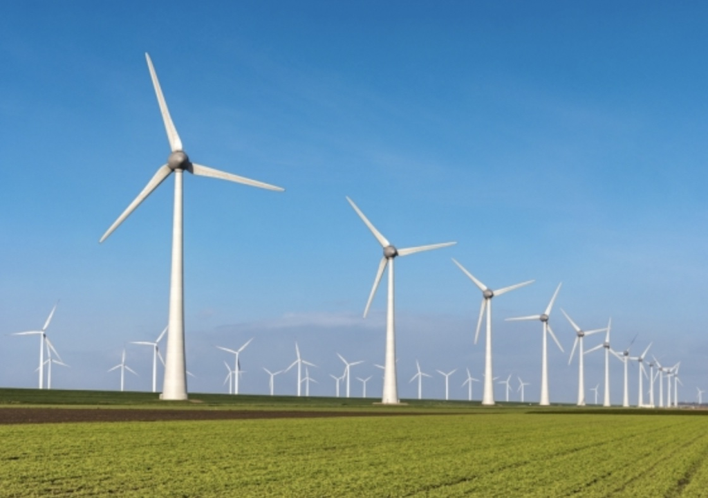

## **Question 2: Univariate Distribution of Turbine Swept Area**

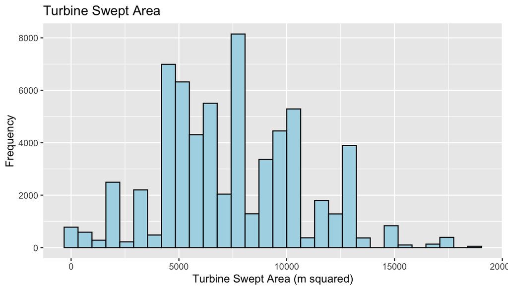

## **Question 3a: Turbine Hub Height vs Turbine Swept Area**

The correlation coefficient of Turbine Swept Area vs Turbine Hub Height is 0.72. This is indicative of a strong, positive correlation between the Turbine Hub Height predictor variable and the Turbine Swept area outcome variable. Generally, as the hub height of the turbine increases, the turbine swept area increases as well. The reason for this correlation may be because a larger swept area needs a taller foundation to maintain the overall proportion of the turbine.

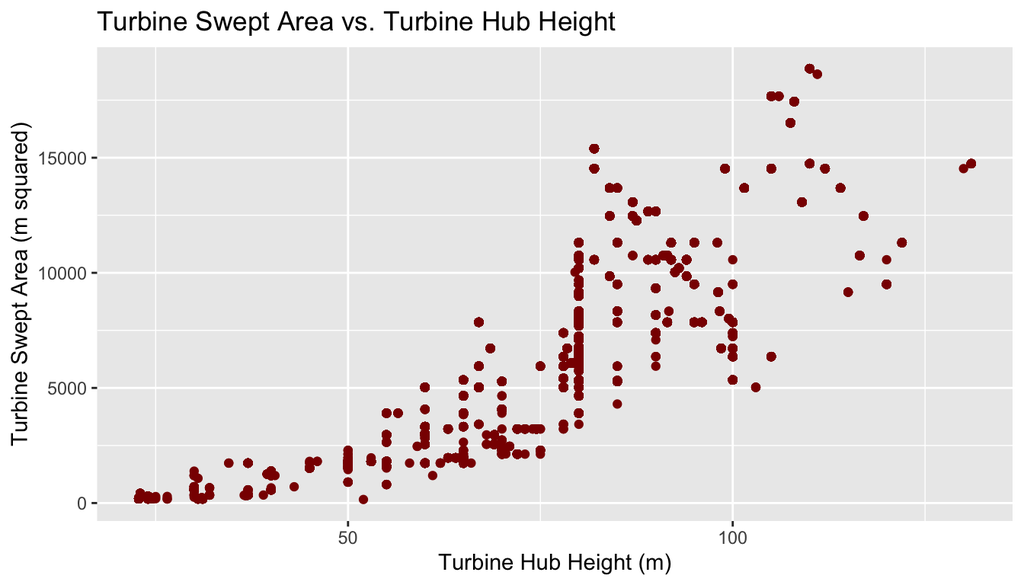

## **Question 3b: Turbine Rotor Diameter vs Turbine Swept Area**

The correlation coefficient of Turbine Rotor Diameter vs Turbine Swept Area is 0.98. This number indicates an exceptionally strong, positive correlation as 0.98 is very close to the correlation coefficient of 1. The reason for this strong of a correlation is due to the equation for the area of a circle $A=\pi r^2$. Since the radius is $0.5*Diameter$, The correlation between radius to turbine swept area and between diameter to turbine swept area are the same. Due to the relation between diameter and area of a circle, the correlation is very strong.

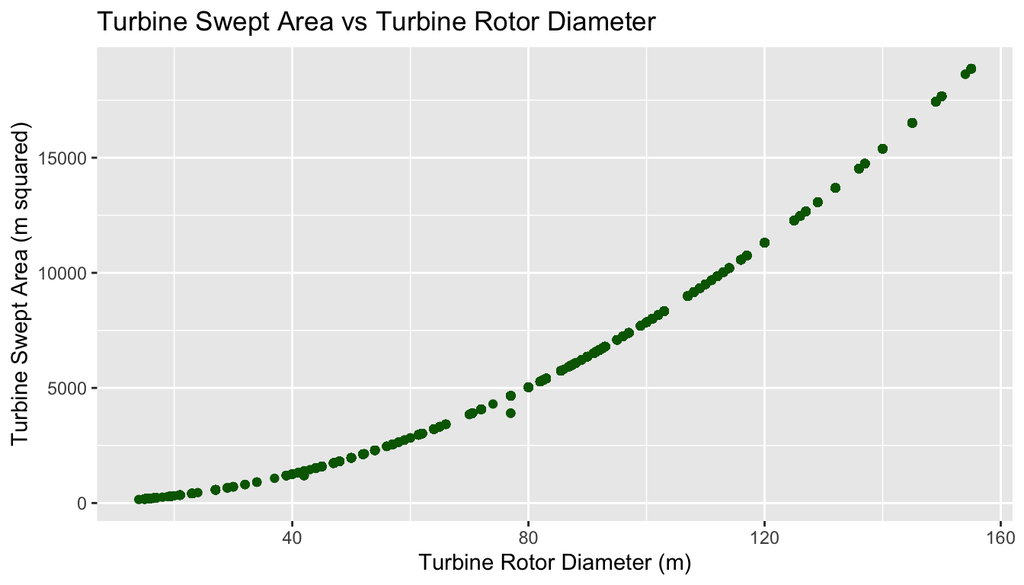

## **Question 3c: Turbine Total Height vs Turbine Swept Area**

The correlation coefficient of Turbine Total Height vs Turbine Swept Area is 0.89. This number indicates a strong, positive correlation between the Turbine Total Height predictor variable and the Turbine Swept Area outcome variable. This implies that as the total height of the turbine increases, the turbine swept area generally increases as well. Similarly to the graph in **Question 3a**, the reason for this correlation may be because a larger swept area requires a taller overall turbine height to maintain the proportion of the turbine.

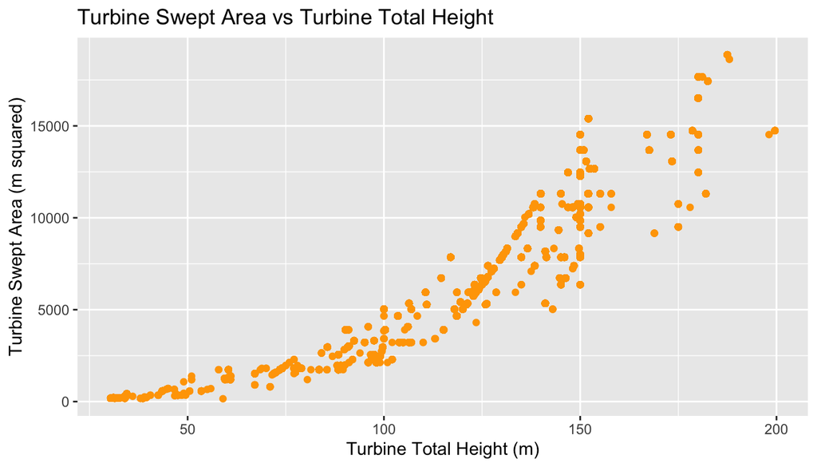

## **Question 4: Conclusion**

Through looking at the bivariate graphs for **Turbine Swept Area vs. Turbine Hub Height**, **Turbine Swept Area vs Turbine Rotor Diameter**, and **Turbine Swept Area vs Turbine Total Height**, we can see that all three have strong, positive correlations through their respective correlation coefficients ranging from 0.72 to 0.98. Though **Question 3a** and **Question 3c** both deal with the height of the turbine, the correlation coefficient of **Turbine Total Height vs Turbine Swept Area** is greater than the correlation of **Turbine Hub Height vs Turbine Swept Area**. The reasoning between this discrepancy may be because the Turbine Total Height datapoints account for the height of the rotor as well. Due to this additional measurement, the proportion of the total height to turbine swept area has a stronger correlation as it maximizes efficiency, support, and performance of the turbines due to these proportions.

For future investigation, we could observe wind power in different geographic locations to determine the effects that weather and climate have on the dataset. Other possible future areas of reference also include observing the effects of older vs newer turbines and determining the effects of turbine material to see if there is any effect on turbine swept area as well.

## **References**

1. Hoen, B.D., Diffendorfer, J.E., Rand, J.T., Kramer, L.A., Garrity, C.P., and Hunt, H.E., 2018, United States Wind Turbine Database (ver. 5.1, August 2022): U.S. Geological Survey, American Clean Power (ACP) Association, and Lawrence Berkeley National Laboratory data release, https://doi.org/10.5066/F7TX3DN0.
2. “How Wind Power Is Leading America’s Energy Transition.” CNBC, CNBC, 13 Mar. 2021, https://www.cnbc.com/2021/03/13/how-wind-became-americas-top-renewable-electricity-source.html.
3. “Taller, Faster, Better, Stronger. Wind Towers Are Only Getting Bigger.” UNSW Newsroom, 17 July 2019 [Photograph], https://newsroom.unsw.edu.au/news/science-tech/taller-faster-better-stronger-wind-towers-are-only-getting-bigger.